# RB_HW9

## (B)

```r
#liner model
lsModel<- lm(medv~., data= Boston)
summary(lsModel)
```

```
##
## Call:
## lm(formula = medv ~ ., data = Boston)
##
## Residuals:
##     Min      1Q  Median      3Q     Max
## -15.595  -2.730  -0.518   1.777  26.199
##
## Coefficients:
##               Estimate Std. Error t value Pr(>|t|)
## (Intercept)  3.646e+01  5.103e+00   7.144 3.28e-12 ***
## crim        -1.080e-01  3.286e-02  -3.287 0.001087 **
## zn           4.642e-02  1.373e-02   3.382 0.000778 ***
## indus        2.056e-02  6.150e-02   0.334 0.738288
## chas         2.687e+00  8.616e-01   3.118 0.001925 **
## nox         -1.777e+01  3.820e+00  -4.651 4.25e-06 ***
## rm           3.810e+00  4.179e-01   9.116  < 2e-16 ***
## age          6.922e-04  1.321e-02   0.052 0.958229
## dis         -1.476e+00  1.995e-01  -7.398 6.01e-13 ***
## rad          3.060e-01  6.635e-02   4.613 5.07e-06 ***
## tax         -1.233e-02  3.760e-03  -3.280 0.001112 **
## ptratio     -9.527e-01  1.308e-01  -7.283 1.31e-12 ***
## black        9.312e-03  2.686e-03   3.467 0.000573 ***
## lstat       -5.248e-01  5.072e-02 -10.347  < 2e-16 ***
## ---
## Signif. codes:  0 '***' 0.001 '**' 0.01 '*' 0.05 '.' 0.1 ' ' 1
##
## Residual standard error: 4.745 on 492 degrees of freedom
## Multiple R-squared:  0.7406, Adjusted R-squared:  0.7338
## F-statistic: 108.1 on 13 and 492 DF,  p-value: < 2.2e-16
```

```r
confint(lsModel)
```

```
##                     2.5 %        97.5 %
## (Intercept)  26.432226009  46.486750761
## crim         -0.172584412  -0.043438304
## zn            0.019448778   0.073392139
## indus        -0.100267941   0.141385193
## chas          0.993904193   4.379563446
## nox         -25.271633564 -10.261588893
## rm            2.988726773   4.631003640
## age          -0.025262320   0.026646769
## dis          -1.867454981  -1.083678710
## rad           0.175692169   0.436406789
## tax          -0.019723286  -0.004945902
## ptratio      -1.209795296  -0.695699168
## black         0.004034306   0.014589060
## lstat        -0.624403622  -0.425113133
```

Comparing the Bayesian linear regression model in part a (uninformative prior) to the frequentist linear regression model. I don’t see in major difference in the parameter means , sd and ci. It appears that both methods produce near identical results.

## (C)

```r
#model with double exponential prior
model_string <- textConnection("model{
   # Likelihood
   for(i in 1:n){
      Y[i] ~ dnorm(alpha+inprod(X[i,],beta[]),taue)
   }
   # Priors
   for(j in 1:p){
      beta[j] ~ dnorm(0,taue * taub)
   }
   alpha ~ dnorm(0,0.001)
   taue  ~ dgamma(0.1, 0.1)
   taub  ~ dgamma(0.1, 0.1)
}")


model <- jags.model(model_string,data = data, n.chains=2,quiet=TRUE)


update(model, 10000, progress.bar="none")


params <- c("beta", "alpha")
samples <- coda.samples(model,variable.names=params,n.iter=20000,thin=10,  progress.bar="none")

#summary data
summary(samples)
```

```
##
## Iterations = 10010:30000
## Thinning interval = 10
## Number of chains = 2
## Sample size per chain = 2000
##
## 1. Empirical mean and standard deviation for each variable,
##    plus standard error of the mean:
##
##               Mean       SD  Naive SE Time-series SE
## alpha    27.200577 4.397473 6.953e-02      5.390e-01
## beta[1]  -0.100696 0.033399 5.281e-04      5.256e-04
## beta[2]   0.049082 0.013858 2.191e-04      3.816e-04
## beta[3]  -0.037788 0.059721 9.443e-04      1.974e-03
## beta[4]   2.053979 0.806807 1.276e-02      1.463e-02
## beta[5]  -3.388940 2.585167 4.088e-02      1.460e-01
## beta[6]   3.778021 0.417929 6.608e-03      3.853e-02
## beta[7]  -0.009605 0.013038 2.062e-04      4.603e-04
## beta[8]  -1.251994 0.192771 3.048e-03      7.277e-03
## beta[9]   0.278715 0.064751 1.024e-03      2.625e-03
## beta[10] -0.013768 0.003712 5.870e-05      1.891e-04
## beta[11] -0.797657 0.126024 1.993e-03      8.714e-03
## beta[12]  0.010200 0.002742 4.336e-05      9.491e-05
## beta[13] -0.552800 0.053031 8.385e-04      2.245e-03
##
## 2. Quantiles for each variable:
##
##                2.5%       25%       50%        75%     97.5%
## alpha     19.216899 24.003593 26.996488 30.3708590 35.823949
## beta[1]   -0.165696 -0.123290 -0.101197 -0.0779845 -0.035238
## beta[2]    0.021851  0.039913  0.049154  0.0585053  0.075581
## beta[3]   -0.156746 -0.078450 -0.037251  0.0036040  0.079332
## beta[4]    0.506971  1.499188  2.037410  2.5768760  3.680475
## beta[5]  -10.209944 -4.544542 -2.972657 -1.6762816  0.287090
## beta[6]    2.963721  3.485775  3.760179  4.0735379  4.594506
## beta[7]   -0.035099 -0.018381 -0.009742 -0.0007248  0.016224
## beta[8]   -1.622715 -1.386308 -1.253055 -1.1181530 -0.876339
## beta[9]    0.149319  0.236247  0.278765  0.3213161  0.403829
## beta[10]  -0.021125 -0.016207 -0.013862 -0.0112682 -0.006443
## beta[11]  -1.043383 -0.881691 -0.799766 -0.7146527 -0.547169
## beta[12]   0.004923  0.008351  0.010203  0.0120711  0.015638
## beta[13]  -0.658319 -0.589366 -0.552683 -0.5163411 -0.449954
```

## (D)

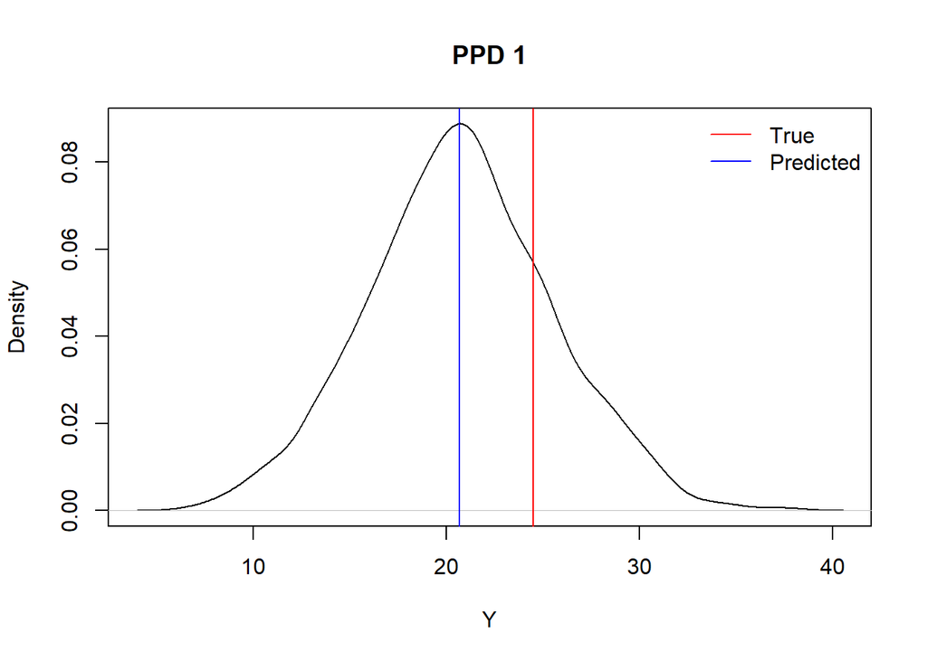

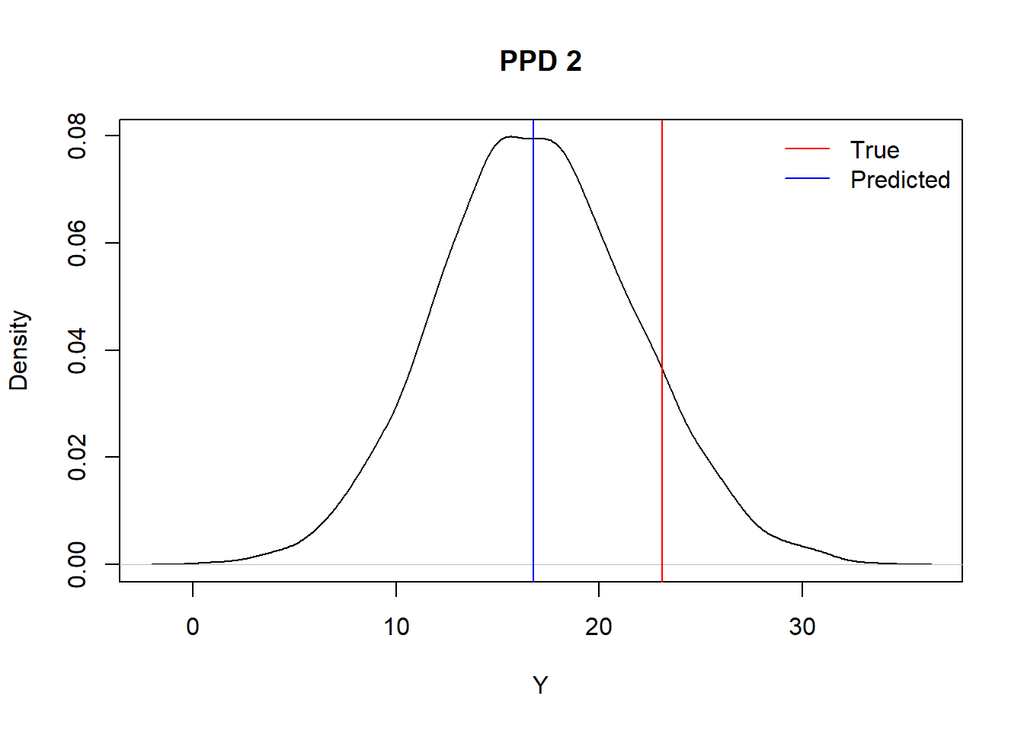

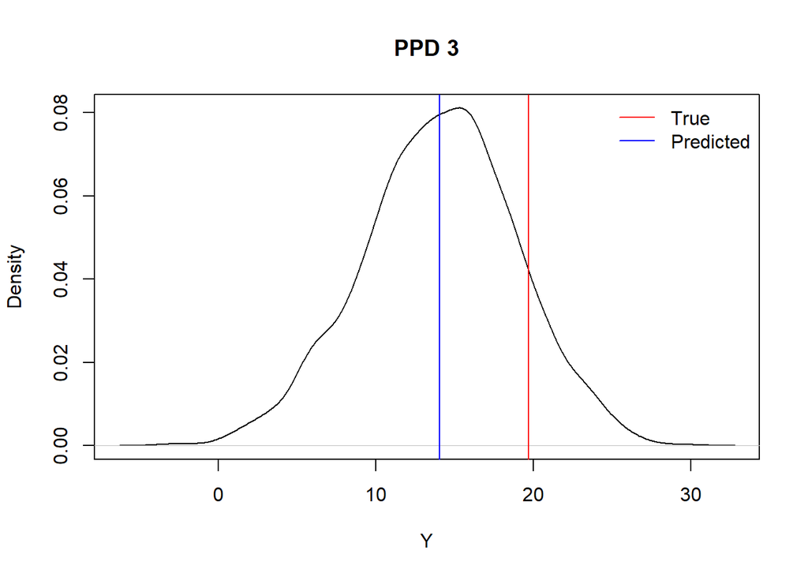

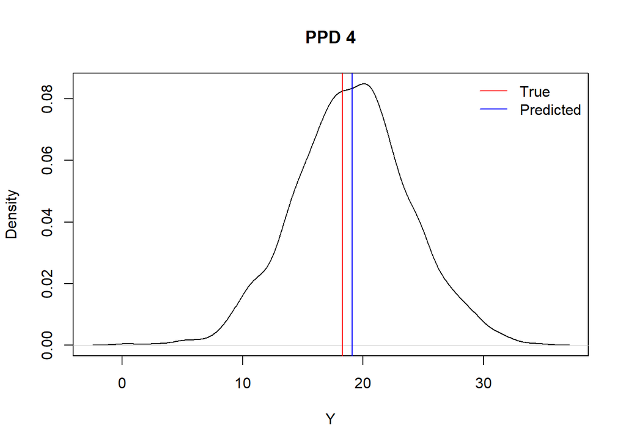

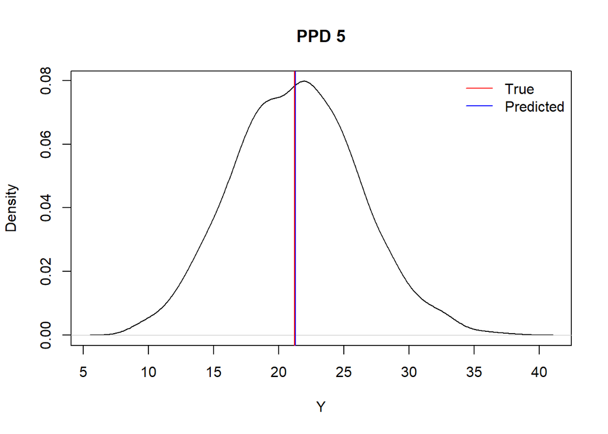

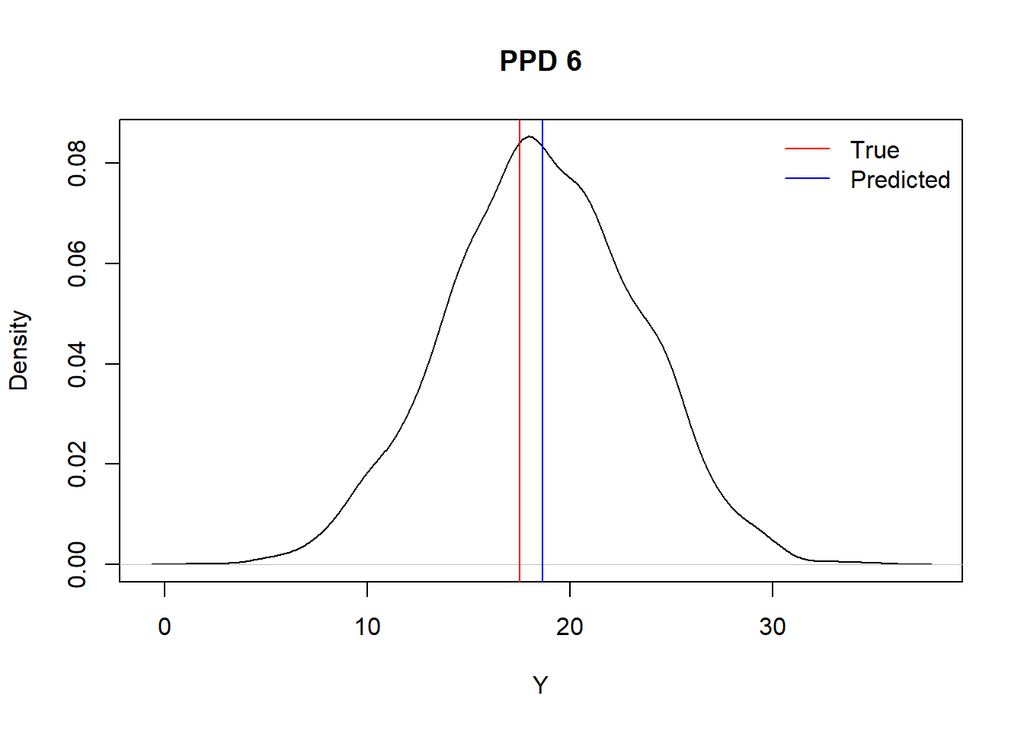

```r
##data
#taking the frist 500 rows
y<- Boston$medv[1:500]

#taking the covar, 500 rows
x<- (Boston[1:13])[1:500,]

##ppd data to be passed to JAGS
yPp<- y[495:500]
xPp<- x[495:500, ]
#scaling matrix
X_<- as.matrix(xPp)


#obs Data to be passed to JAGS
Y<- y[1:494]
xob<- x[1:494, ]
#scaling
X<- as.matrix(xob)


# of obs in obs matrix
n <- length(Y)
p <- ncol(xob)

# of obs in predi matrix
n_<- length(yPp)

data   <- list(Y=Y,X=X,n=n,p=p, n_= n_, X_= X_)

#jags model
model_string <- textConnection("model{
   # Likelihood
   for(i in 1:n){
    Y[i] ~ dnorm(alpha+inprod(X[i,],beta[]),taue)
   }

   # Priors
   for(j in 1:p){
    beta[j] ~ dnorm(0,0.001)

   }

   alpha ~ dnorm(0,0.001)
   taue  ~ dgamma(0.1, 0.1)

  #prediction
   for(i in 1:n_){
    Y_[i] ~ dnorm(alpha+inprod(X_[i,],beta[]),taue)
   }

}")


model <- jags.model(model_string,data = data, n.chains=2,quiet=TRUE)
update(model, 10000, progress.bar="none")
params <- c("Y_")

samples <- coda.samples(model,variable.names=params,n.iter=20000,thin=10,  progress.bar="none")

preM<- summary(samples)

pMean<- preM$statistics[,1]

sub<- samples[[1]]

#plot the ppd
for(i in 1:length(yPp)){
  plot(density(sub[,i]),xlab="Y",main=paste("PPD", i))
  #true means
  abline(v = yPp[i], col= "red")
  #pred means
  abline(v= pMean[i], col = "blue")
  legend("topright", legend = c("True", "Predicted"),col=c("red", "blue"), lty=c(1,1), bty = "n")
}
```

I think the predictions are reasonable, The above plots indicate this for each of the 6 plots showing the predicted means(blue) with the true means( red). As we can see these values are not too far apart.